# ECo 634 - Analysis of Environmental Data Lab

Lab 05: Modeling Errors

Michael France Nelson

Fall 2020

## Question 01: Exponential plots

Instructions:

1. Complete the template R code to build your exponential function. Make sure you read the note about parameter `b` in the lab instructions.
2. To gain visual intuition, try using `curve()` to plot your function.
- Try out different values of the two parameters as well as plotting over different ranges of x-values.
- Try plotting two or more curves with slightly different parameter values on the same plot
- You may need to try out different ranges of x-values in your plot windows to make sure you are focusing on the interesting parts of the curves.
- Try different line colors, widths, and textures.

An example exploratory plotting exercise:

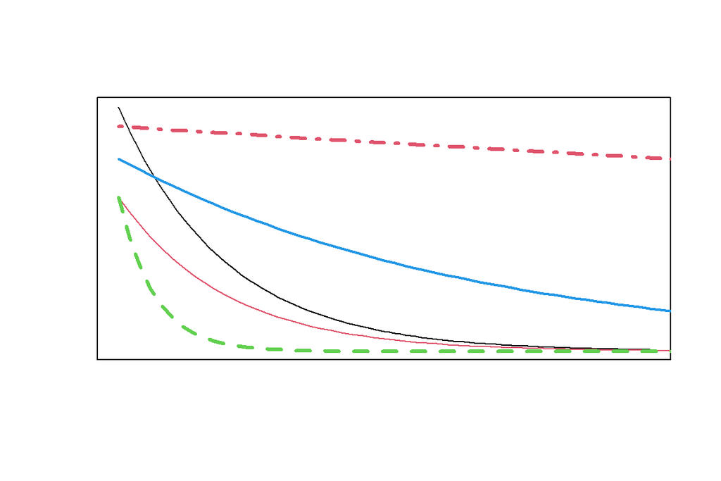

### Questions

- Q1 (2 pts.) Paste the R code you used to create `exp_fun()`
- Q2 (3 pts.) Create a single plot containing 4 curves with these parameter values:
  - curve 1: a = 1.9, b = 0.1, line color = black, line texture = solid
  - curve 2: a = 1.9, b = 0.3, line color = black, line texture = dotted
  - curve 3: a = 1.2, b = 0.2, line color = red, line texture = solid
  - curve 4: a = 1.2, b = 0.4, line color = red, line texture = dotted

### Solution

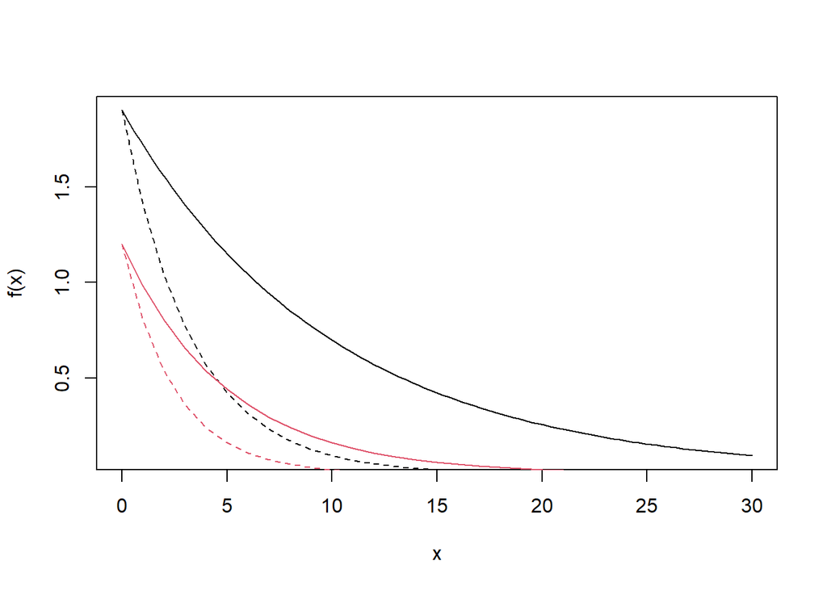

```r
exp_fun = function(x, a, b)
{
  return(a * exp(-b * x))
}


# curve(exp_fun(x, 1.9, 0.1), add = FALSE, from = 0, to = 30, ann = FALSE, axes = FALSE); box()
curve(exp_fun(x, 1.9, 0.1), add = FALSE, from = 0, to = 30, ylab = "f(x)")
curve(exp_fun(x, 1.9, 0.3), add = TRUE, from = 0, to = 100, col = 1, lty = 2)
curve(exp_fun(x, 1.2, 0.2), add = TRUE, from = 0, to = 100, col = 2, lty = 1)
curve(exp_fun(x, 1.2, 0.4), add = TRUE, from = 0, to = 100, col = 2, lty = 2)
```

## Question 02: Exponential parameters

> Consider the plot you made with the 4 exponential curves.

Observe how the curves vary as you change the two parameters’ values.

### Questions

- Q1 (2 pts.) Qualitatively describe what happens to the curve as you vary parameter `a`
- Q2 (2 pts.) Qualitatively describe what happens to the curve as you vary parameter `b`

### Solution

- Parameter `a` sets the y-intercept.
- Parameter `b` sets the [initial] steepness of the decay.
- Students may notice that a also affects the steepness of the decay.

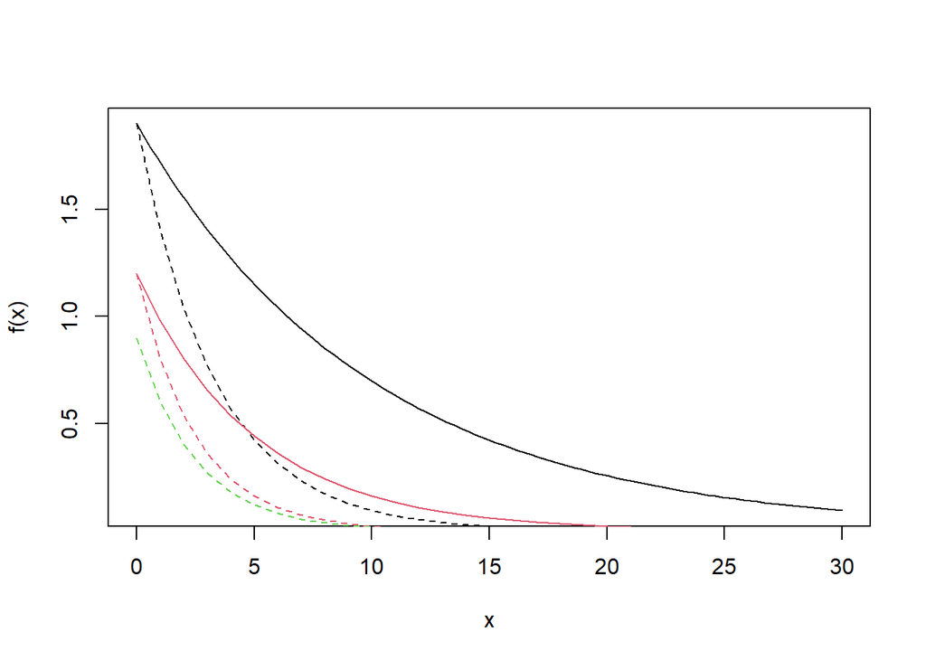

```r
exp_fun = function(x, a, b)
{
  return(a * exp(-b * x))
}

curve(exp_fun(x, 1.9, 0.1), add = FALSE, from = 0, to = 30,  col = 1, ylab = "f(x)")
curve(exp_fun(x, 1.9, 0.3), add = TRUE,  from = 0, to = 100, col = 1, lty = 2)
curve(exp_fun(x, 1.2, 0.2), add = TRUE,  from = 0, to = 100, col = 2, lty = 1)
curve(exp_fun(x, 1.2, 0.4), add = TRUE,  from = 0, to = 100, col = 2, lty = 2)
curve(exp_fun(x, 0.9, 0.4), add = TRUE,  from = 0, to = 100, col = 3, lty = 2)
```

## Question 03: Ricker plots

Instructions:

1. To gain visual intuition, try using `curve()` to plot the Ricker function.
- Try out different values of the two parameters as well as plotting over different ranges of x-values.
- Try plotting two or more curves with slightly different parameter values on the same plot
- You may need to try out different ranges of x-values in your plot windows to make sure you are focusing on the interesting parts of the curves.
- Try different line colors, widths, and textures.

An example exploratory plotting exercise:

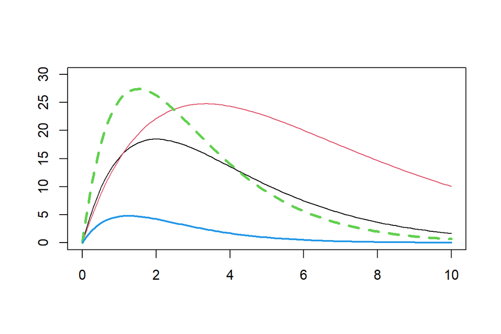

### Solution

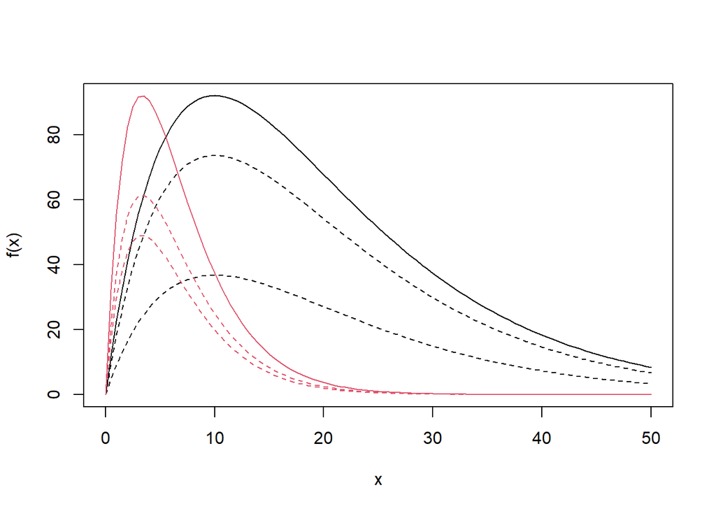

```r
curve(ricker_fun(x, 25, 0.1), add = FALSE, from = 0, to = 50, ylab = "f(x)")
curve(ricker_fun(x, 20, 0.1), add = TRUE, col = 1, lty = 2)
curve(ricker_fun(x, 10, 0.1), add = TRUE, col = 1, lty = 2)
curve(ricker_fun(x, 75, 0.3), add = TRUE, col = 2, lty = 1)
curve(ricker_fun(x, 50, 0.3), add = TRUE, col = 2, lty = 2)
curve(ricker_fun(x, 40, 0.3), add = TRUE, col = 2, lty = 2)
```

## Question 04: Ricker params

Instructions:

1. To gain visual intuition, try using `curve()` to plot the Ricker function.
- Try out different values of the two parameters as well as plotting over different ranges of x-values.
- Try plotting two or more curves with slightly different parameter values on the same plot
- You may need to try out different ranges of x-values in your plot windows to make sure you are focusing on the interesting parts of the curves.
- Try different line colors, widths, and textures.

An example exploratory plotting exercise:

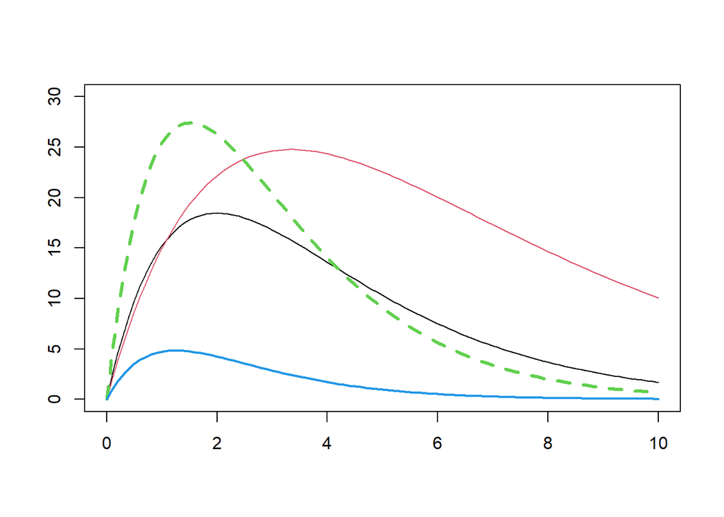

### Questions

- Q1 (2 pts.) Qualitatively describe how the `a` parameter influences the curve shape.
- Q2 (2 pts.) Qualitatively describe how the `b` parameter influences the curve shape.

NOTE: make sure you choose an appropriate range of x-values in your plot.

### Solution

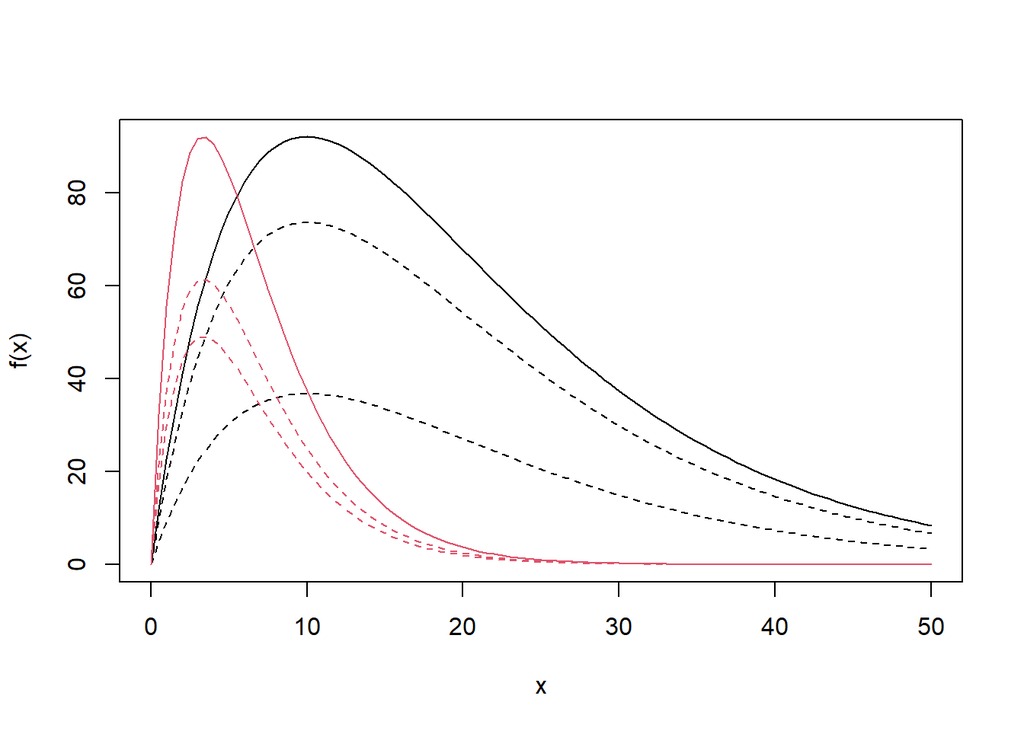

```r
curve(ricker_fun(x, 25, 0.1), add = FALSE, from = 0, to = 50, ylab = "f(x)")
curve(ricker_fun(x, 20, 0.1), add = TRUE, col = 1, lty = 2)
curve(ricker_fun(x, 10, 0.1), add = TRUE, col = 1, lty = 2)
curve(ricker_fun(x, 75, 0.3), add = TRUE, col = 2, lty = 1)
curve(ricker_fun(x, 50, 0.3), add = TRUE, col = 2, lty = 2)
curve(ricker_fun(x, 40, 0.3), add = TRUE, col = 2, lty = 2)
```

## Question 05: salamander data scatterplot

Instructions:

1. Read the salamander dispersal data into a `data.frame` called `dat_dispersal`.
2. Create a scatterplot of distance class and dispersal rate of first time breeding salamanders.

### Questions

- Q1 (1 pts.) Upload an image file with your scatterplot. Make sure it has appropriate axis labels and title.
- Q2 (2 pts.) Describe, in nontechnical language, what is shown on the x-axis
- Q3 (2 pts.) Describe, in nontechnical language, what is shown on the y-axis

### Solution

```r
dat_dispersal
```

```
##    dist.class disp.rate.ftb disp.rate.eb
## 1         100          0.00          0.0
## 2         200          0.25          0.8
## 3         300          0.65          0.2
## 4         400          0.92          0.1
## 5         500          0.40          0.3
## 6         600          0.00          0.0
## 7         800          0.20          0.0
## 8         900          0.05          0.0
## 9        1000          0.00          0.0
## 10       1100          0.15          0.0
## 11       1200          0.00          0.0
## 12       1300          0.12          0.0
## 13       1400          0.00          0.0
## 14       1500          0.00          0.0
```

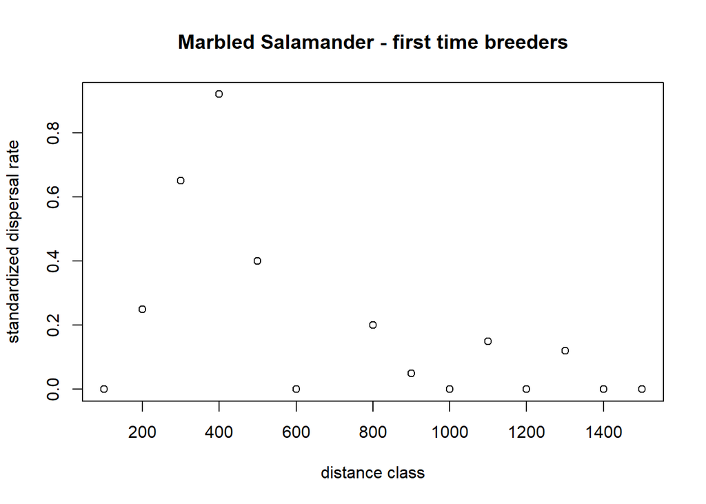

```r
plot(dat_dispersal$dist.class, dat_dispersal$disp.rate.ftb, xlab = "distance class", ylab = "standardized dispersal rate", main = "Marbled Salamander - first time breeders")
```

## Question 06: salamander linear model

> Recall the function we have used to visually estimate linear model parameters:

```r
# Calculates the value of x for a linear function, given the coordinates
# of a known point (x1, y1) and the slope of the line.
line_point_slope = function(x, x1, y1, slope)
{
  get_y_intercept =
    function(x1, y1, slope)
      return(-(x1 * slope) + y1)

  linear =
    function(x, yint, slope)
      return(yint + x * slope)

  return(linear(x, get_y_intercept(x1, y1, slope), slope))
}
```

Instructions:

1. Using the scatterplot of the dispersal data, visually fit a linear mode

### Questions

- Q1 (2 pts.) Upload an image file with your scatterplot and fitted line. Make sure it has appropriate axis labels and title.

### Solution

```r
line_point_slope = function(x, x1, y1, slope)
{
  get_y_intercept =
    function(x1, y1, slope)
      return(-(x1 * slope) + y1)

  linear =
    function(x, yint, slope)
      return(yint + x * slope)

  return(linear(x, get_y_intercept(x1, y1, slope), slope))
}
```

For example:

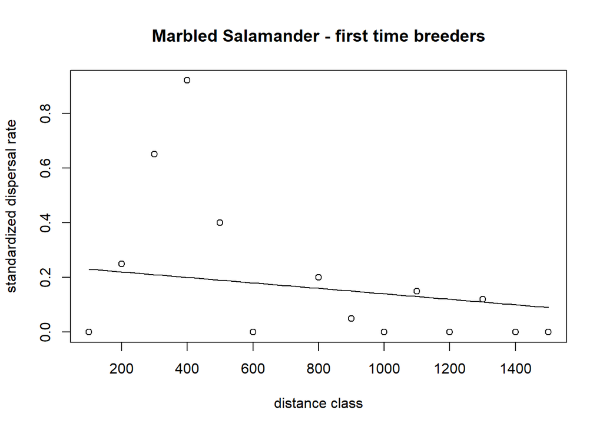

```r
plot(dat_dispersal$dist.class, dat_dispersal$disp.rate.ftb, xlab = "distance class", ylab = "standardized dispersal rate", main = "Marbled Salamander - first time breeders")
curve(line_point_slope(x, 1400, 0.1, -0.0001), add = TRUE)
```

## Question 07: salamander exponential model

Instructions:

1. Using the scatterplot of the dispersal data, visually fit an model

### Questions

- Q1 (4 pts.) Upload an image file with your scatterplot and fitted curve. Make sure it has appropriate axis labels and title.

### Solution

```r
exp_fun = function(x, a, b) { return(a * exp(-b * x))}
```

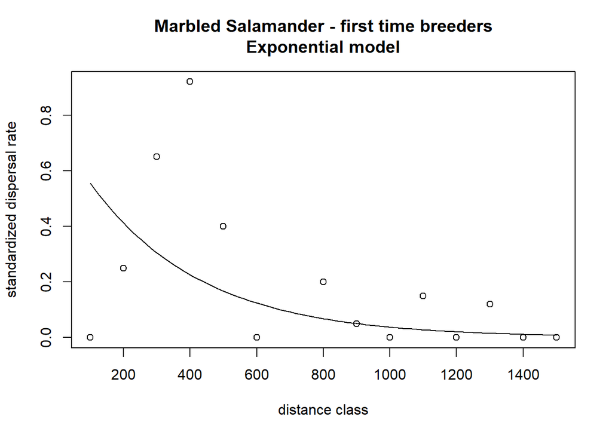

```r
plot(dat_dispersal$dist.class, dat_dispersal$disp.rate.ftb, xlab = "distance class", ylab = "standardized dispersal rate",
     main = "Marbled Salamander - first time breeders\nExponential model")
curve(exp_fun(x, 0.75, 0.003), add = TRUE)
```

## Question 08: salamander ricker model

Instructions:

1. Using the scatterplot of the dispersal data, visually fit a ricker curve model.

### Questions

- Q1 (4 pts.) Upload an image file with your scatterplot and fitted curve. Make sure it has appropriate axis labels and title.

### Solution

```r
ricker_fun = function(x, a, b) { return(a * x * exp(-b * x))}
```

For example:

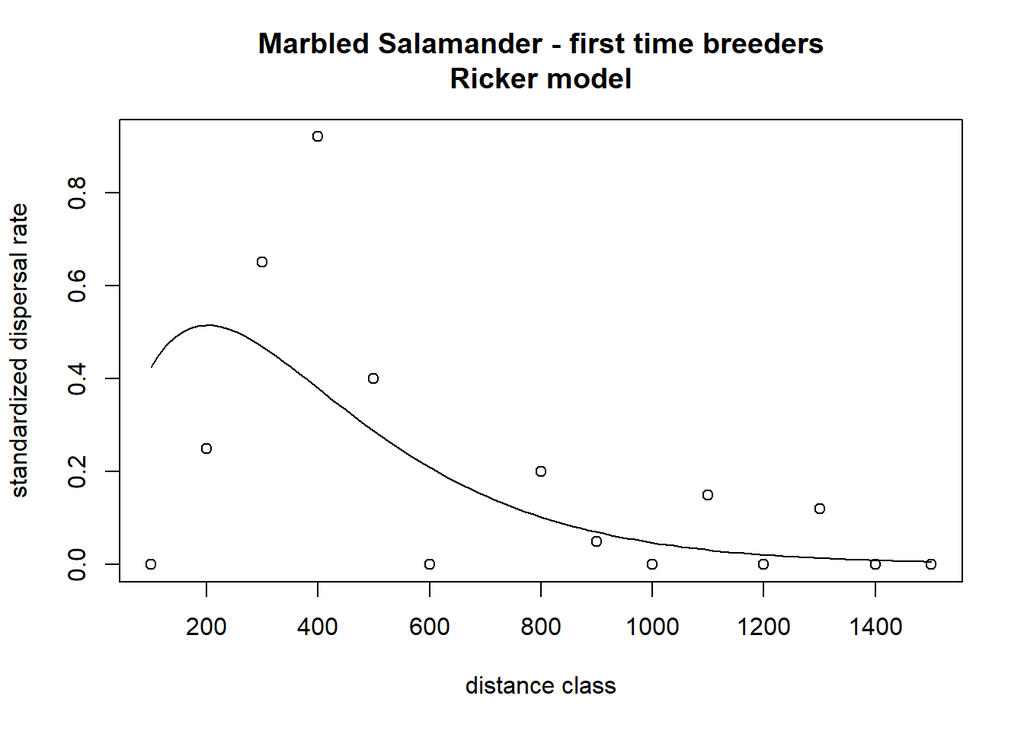

```r
plot(dat_dispersal$dist.class, dat_dispersal$disp.rate.ftb, xlab = "distance class", ylab = "standardized dispersal rate",
     main = "Marbled Salamander - first time breeders\nRicker model")
curve(ricker_fun(x, 0.007, 1/200), add = TRUE)
```

## Question 09: salamander linear model residuals

> Recall the function we have used to visually estimate linear model parameters:

```r
# Calculates the value of x for a linear function, given the coordinates
# of a known point (x1, y1) and the slope of the line.
line_point_slope = function(x, x1, y1, slope)
{
  get_y_intercept =
    function(x1, y1, slope)
      return(-(x1 * slope) + y1)

  linear =
    function(x, yint, slope)
      return(yint + x * slope)

  return(linear(x, get_y_intercept(x1, y1, slope), slope))
}
```

Instructions:

1. Using the parameters you chose for your linear fit, calculate the residuals and store them in a vector `resids_linear`.

### Questions

- Q1 (3 pts.) Paste the code you used to create `resids_linear`.
- Q1 (1 pts.) Upload an image file with a histogram of the residuals of your linear model.

### Solution

```r
line_point_slope = function(x, x1, y1, slope)
{
  get_y_intercept =
    function(x1, y1, slope)
      return(-(x1 * slope) + y1)

  linear =
    function(x, yint, slope)
      return(yint + x * slope)

  return(linear(x, get_y_intercept(x1, y1, slope), slope))
}
```

For example:

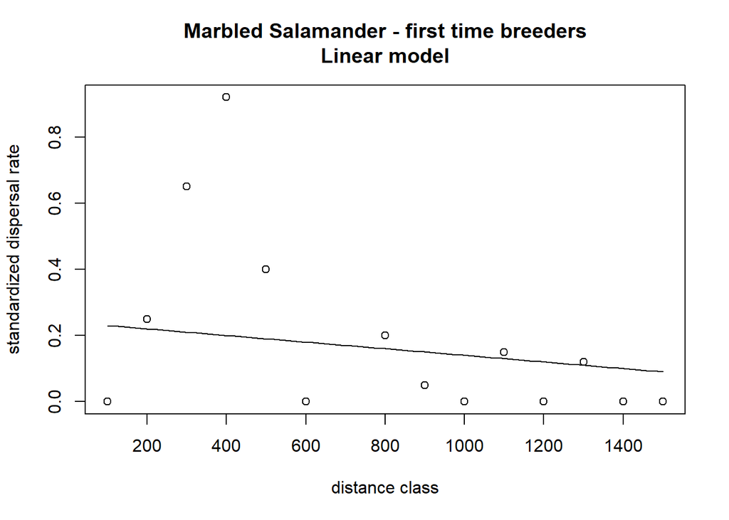

```r
param_x1 = 1400
param_y1 = 0.1
param_slope = -0.0001

plot(dat_dispersal$dist.class, dat_dispersal$disp.rate.ftb, xlab = "distance class", ylab = "standardized dispersal rate", main = "Marbled Salamander - first time breeders\nLinear model")
curve(line_point_slope(x, param_x1, param_y1, param_slope), add = TRUE)
```

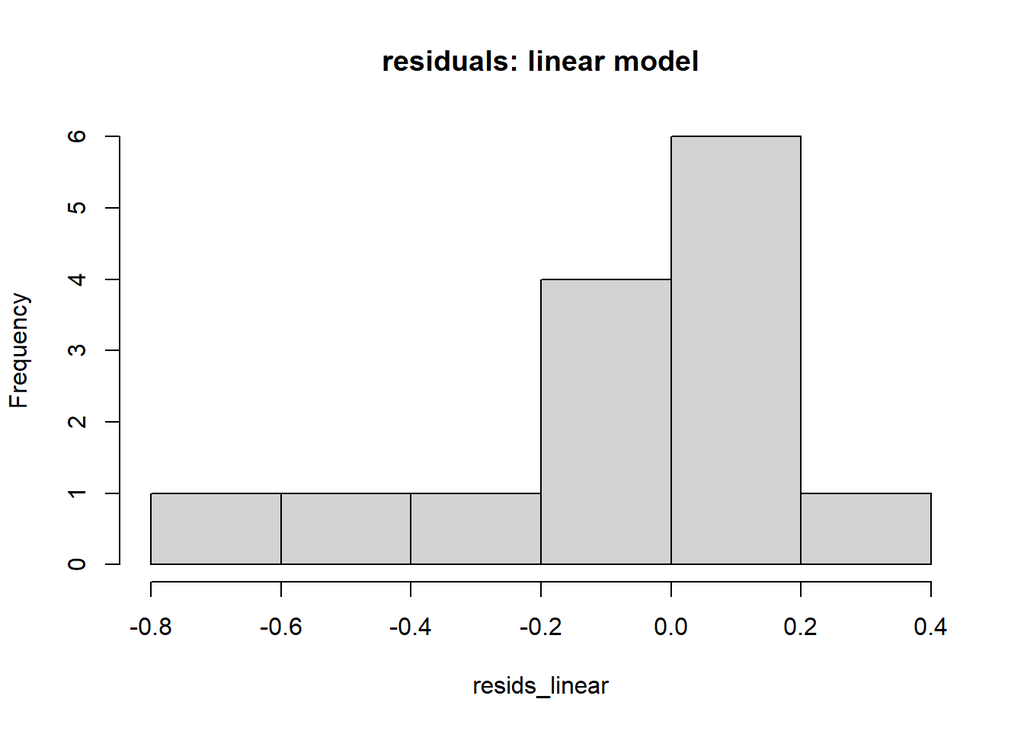

```r
resids_linear =
line_point_slope(dat_dispersal$dist.class, param_x1, param_y1, param_slope) - dat_dispersal$disp.rate.ftb


hist(resids_linear, main = "residuals: linear model")
```

## Question 10: salamander exponential model residuals

Instructions:

1. Using the parameters you chose for your exponential fit, calculate the residuals and store them in a vector `resids_exp`.

### Questions

- Q1 (4 pts.) Upload an image file with a histogram of the residuals of your exponential model.

### Solution

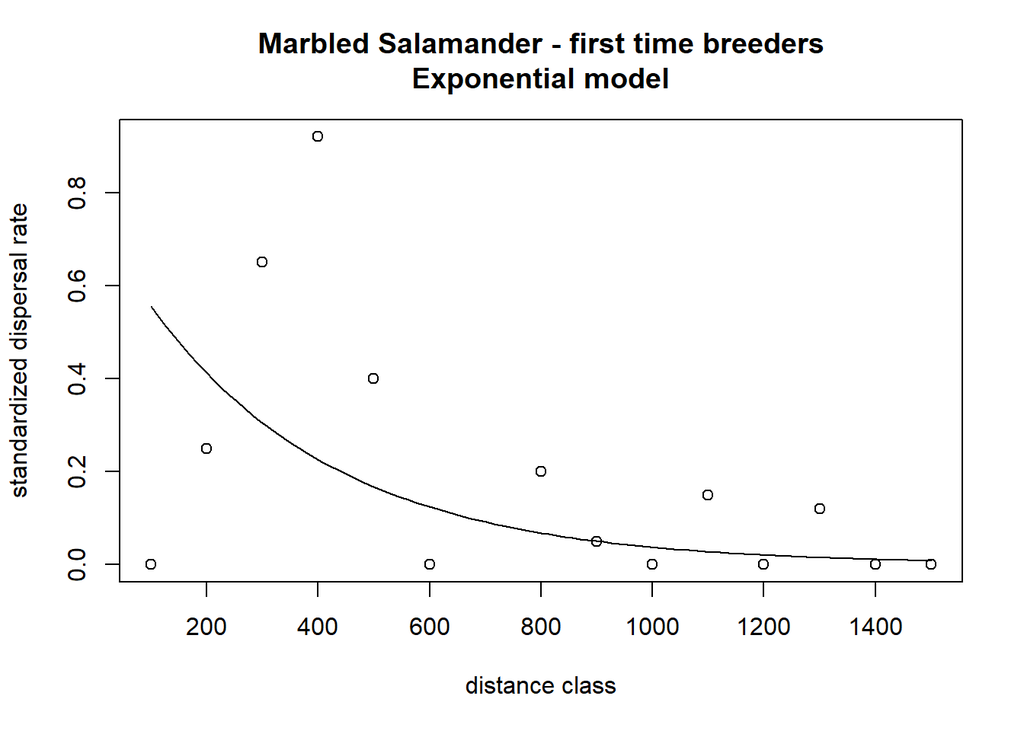

```r
exp_fun = function(x, a, b) { return(a * exp(-b * x))}
plot(dat_dispersal$dist.class,
     dat_dispersal$disp.rate.ftb,
     xlab = "distance class", ylab = "standardized dispersal rate",
     main = "Marbled Salamander - first time breeders\nExponential model")
exp_a = 0.75
exp_b = 0.003
curve(exp_fun(x, exp_a, exp_b), add = TRUE)
```

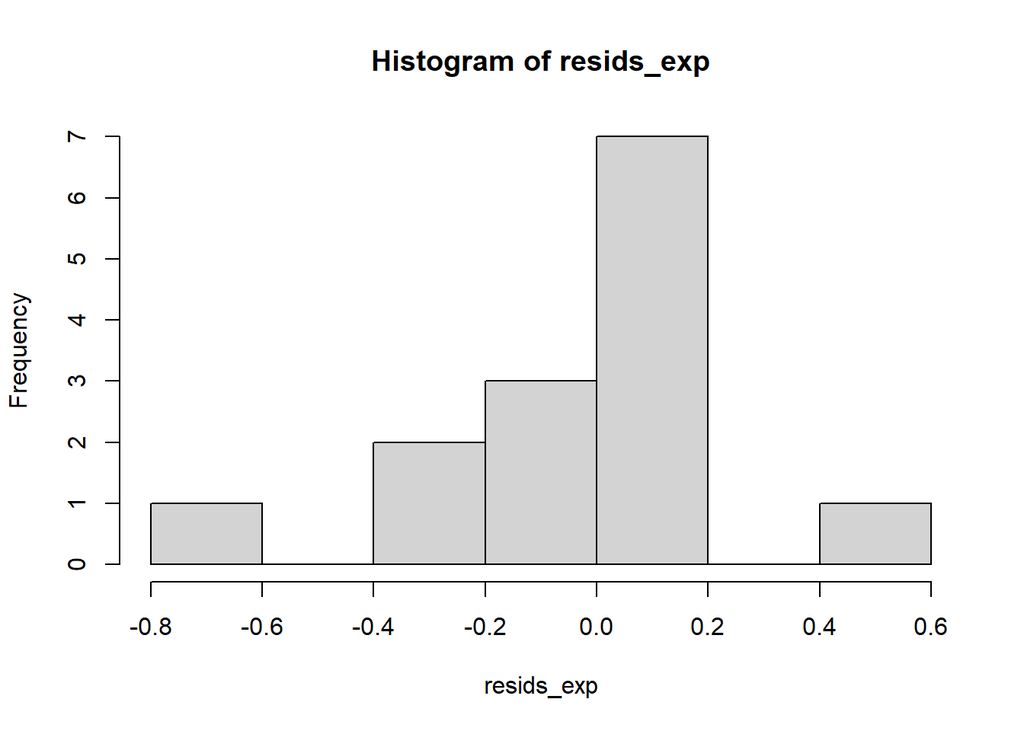

```r
resids_exp = exp_fun(dat_dispersal$dist.class, exp_a, exp_b) - dat_dispersal$disp.rate.ftb
hist(resids_exp)
```

## Question 11: salamander ricker model residuals

Instructions:

1. Using the parameters you chose for your Ricker curve fit, calculate the residuals and store them in a vector `resids_ricker`.
2. Using the scatterplot of the dispersal data, visually fit a ricker curve model.

### Questions

- Q1 (4 pts.) Upload an image file with a histogram of the residuals of your Ricker curve model.

### Solution

```r
ricker_fun = function(x, a, b) { return(a * x * exp(-b * x))}
```

For example:

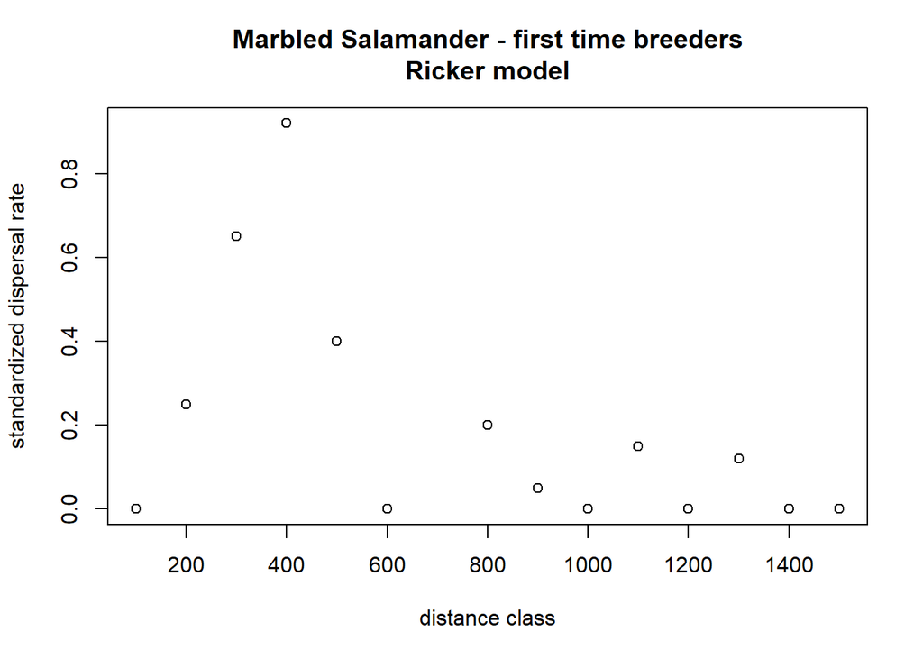

```r
plot(
  dat_dispersal$dist.class, dat_dispersal$disp.rate.ftb,
  xlab = "distance class", ylab = "standardized dispersal rate",
     main = "Marbled Salamander - first time breeders\nRicker model")
```

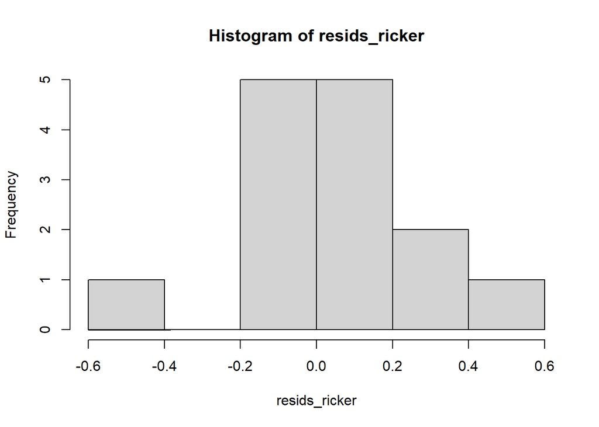

```r
rick_a = 0.007
rick_b = 1/200


resids_ricker = ricker_fun(dat_dispersal$dist.class, rick_a, rick_b) - dat_dispersal$disp.rate.ftb
hist(resids_ricker)


curve(ricker_fun(x, rick_a, rick_b), add = TRUE)
```